# Analysis on 15 years of power outages across the United States

## 1. Motivation

For the final project, I decided to analyze the power outage cases across the United States and find the relationship between power outages with its casues such as physical attack, storm, etc.

Before I came to the United States, I have never thought about the power outage would be a problem and had no such experience. However, since I came here, I have experienced the power outage every time when the storm hit my area. Also, I realized that the power supply system is not quite stable compared to my home country.

At the end of this project, I expected to find that the storm is the major factor and also find out other factors that affected the power outage. In addition to that, I look forward to finding a good machine learning model to predict the number of affected customers by some factors that we are going to find in this tutorial.

## 2. Data Collection & Management

I found an interesting dataset from Kaggle, https://www.kaggle.com/autunno/15-years-of-power-outages.

This dataset contains outage data from 2000 up until 2014, with the following information.

- Event Description: Reason of the outage (e.g. Vandalistm, Severe Weather, etc)
- Year: Year of the outage (e.g. 2014)
- Month: Month of the outage (e.g. November)
- Date Event Began: Date of the outage (e.g. 11/13/2017)
- Time Event Began: Time the outage was registered (e.g. 15:05:00)
- Date of Restoration: Date the outage was resolved
- Time of Restoration: Time the outage was resolved
- Respondent: The company that acted upon the outage
- Geografic Area: Region of the outage (e.g. Missisippi, Texas, New York, Salt Lake City, etc)
- NERG Region: (NERC refers to the North American Electricity Reliability Corporation, formed to ensure the reliability of the grid).
- Demand Loss (MW): How much energy was not transmited/consumed during the outage.
- Number of customers affected: How many consumers (e.g. homes, offices, industry, etc) were left to their devices.
- Tags: Summary event description (e.g. wild fire, vandalism, severe weather)

```python
import numpy as np
import pandas as pd
import matplotlib.pyplot as plt
import seaborn as sns
import sklearn
from sklearn.linear_model import LinearRegression

df = pd.read_csv("outage.csv")
df.head()
```

|  | Event Description | Year | Date Event Began | Time Event Began | Date of Restoration | Time of Restoration | Respondent | Geographic Areas | NERC Region | Demand Loss (MW) | Number of Customers Affected | Tags |
| --- | --- | --- | --- | --- | --- | --- | --- | --- | --- | --- | --- | --- |
| 0 | Severe Weather - Thunderstorms | 2014 | 6/30/2014 | 8:00 PM | 7/2/2014 | 6:30 PM | Exelon Corporation/ComEd | Illinois | RFC | Unknown | 420,000 | severe weather, thunderstorm |
| 1 | Severe Weather - Thunderstorms | 2014 | 6/30/2014 | 11:20 PM | 7/1/2014 | 5:00 PM | Northern Indiana Public Service Company | North Central Indiana | RFC | Unknown | 127,000 | severe weather, thunderstorm |
| 2 | Severe Weather - Thunderstorms | 2014 | 6/30/2014 | 5:55 PM | 7/1/2014 | 2:53 AM | We Energies | Southeast Wisconsin | MRO | 424 | 120,000 | severe weather, thunderstorm |
| 3 | Fuel Supply Emergency - Coal | 2014 | 6/27/2014 | 1:21 PM | Unknown | Unknown | We Energies | Wisconsin | MRO | Unknown | Unknown | fuel supply emergency, coal |
| 4 | Physical Attack - Vandalism | 2014 | 6/24/2014 | 2:54 PM | 6/24/2014 | 2:55 PM | Tennessee Valley Authority | Nashville, Tennessee | SERC | Unknown | Unknown | vandalism, physical |

I am going to choose following columns.

- Event Description
- Year
- Geographic Area
- Number of Customers Affected

So, the "Event Description" column will contain the reason for the outage and I am going to rename it as "Cause". Also, I will go by area and year.

```python
df = df[['Year', 'Event Description', 'Geographic Areas', 'Number of Customers Affected']]
df.rename(columns={'Event Description': 'Cause', 'Geographic Areas' : 'Area', 'Number of Customers Affected':'Affected'}, inplace = True)
df = df[df.Affected != 'Unknown']
df = df.dropna()
df.head(1000)
```

|  | Year | Cause | Area | Affected |
| --- | --- | --- | --- | --- |
| 0 | 2014 | Severe Weather - Thunderstorms | Illinois | 420,000 |
| 1 | 2014 | Severe Weather - Thunderstorms | North Central Indiana | 127,000 |
| 2 | 2014 | Severe Weather - Thunderstorms | Southeast Wisconsin | 120,000 |
| 7 | 2014 | Severe Weather - Thunderstorms | Southeast Michigan | 138,802 |
| 8 | 2014 | Severe Weather - Thunderstorms | Central Minnesota | 55,951 |
| ... | ... | ... | ... | ... |
| 1337 | 2006 | Major Snow Storm | Washington DC, Montgomery and Prince Georges C... | 60,000 |
| 1338 | 2006 | Winter Snow/Ice Storm | Entire Atlantic City Electric territory Southe... | 130,000 |
| 1339 | 2006 | Severe Snow Storm | Northern and Northwestern Virginia | 126,000 |
| 1340 | 2006 | Major Snow Storm | Baltimore Metropolitan and Central Maryland | 180,000 |
| 1341 | 2006 | Severe Windstorm | Western Washington | 140,000 |

1000 rows × 4 columns

Alright, now I need to categorize the data. First, let's take a look at "Cause" column.

```python
print(len(set(df.Cause.values)))
```

```
323
```

As we can see, there are lots of items, about 323. Thankfully, I see a kind of pattern that an event caused by weather tends to include words of Weather, Storn, Cold, Snow, hurricane, etc. So, I am going to standardize them by giving a value that I defined.

```python
df['Reason'] = ''
for idx, row in df.iterrows():
    word = row['Cause'].lower()
    if ('weather' in word or 'storm' in word or 'cold' in word or 'thunder' in word or 'wind' in word or 'ice' in word or 'lightning' in word or 'snow' in word or 'hurricane' in word or
       'tornado' in word or 'fog' in word or 'severe' in word or 'rain' in word or 'strike' in word or 'ice storm'in word ):
        df.loc[idx, 'Reason'] = 'Weather'
    elif ('attack' in word or 'physical' in word or 'vandalism' in word or 'theft' in word):
        df.loc[idx, 'Reason'] = 'Attack'
    elif ('fuel' in word or 'failure' in word or 'system' in word or 'supply' in word or 'emergency' in word or 'voltage' in word or 'interruption' in word or
         'shed' in word or 'load' in word):
        df.loc[idx, 'Reason'] = 'System'
    else:
        df.loc[idx, 'Reason'] = 'Others'

df.head()
```

|  | Year | Cause | Area | Affected | Reason |
| --- | --- | --- | --- | --- | --- |
| 0 | 2014 | Severe Weather - Thunderstorms | Illinois | 420,000 | Weather |
| 1 | 2014 | Severe Weather - Thunderstorms | North Central Indiana | 127,000 | Weather |
| 2 | 2014 | Severe Weather - Thunderstorms | Southeast Wisconsin | 120,000 | Weather |
| 7 | 2014 | Severe Weather - Thunderstorms | Southeast Michigan | 138,802 | Weather |
| 8 | 2014 | Severe Weather - Thunderstorms | Central Minnesota | 55,951 | Weather |

I defined them as follows:

- Weather: literally, events that caused by severe weather
- Attack: includes vandalism, theft, etc. Any kinds of physical attack.
- System: includes events that caused by systemical interruption such as fuel shortage, system failure, etc.
- Others: Miscellaneous events such as public appeals, etc.

```python
df.head(2000)
```

|  | Year | Cause | Area | Affected | Reason |
| --- | --- | --- | --- | --- | --- |
| 0 | 2014 | Severe Weather - Thunderstorms | Illinois | 420,000 | Weather |
| 1 | 2014 | Severe Weather - Thunderstorms | North Central Indiana | 127,000 | Weather |
| 2 | 2014 | Severe Weather - Thunderstorms | Southeast Wisconsin | 120,000 | Weather |
| 7 | 2014 | Severe Weather - Thunderstorms | Southeast Michigan | 138,802 | Weather |
| 8 | 2014 | Severe Weather - Thunderstorms | Central Minnesota | 55,951 | Weather |
| ... | ... | ... | ... | ... | ... |
| 1646 | 2000 | Transmission Line Loss | New Mexico | 500,000 | Others |
| 1647 | 2000 | Transmission Line Loss | Texas | 100,000 | Others |
| 1649 | 2000 | Ice Storm | South Carolina | 81,000 | Weather |
| 1650 | 2000 | Ice Storm | North Carolina & Northern South Carolina | 173,000 | Weather |
| 1651 | 2000 | Ice Storm | South Carolina | 133,000 | Weather |

1292 rows × 5 columns

Arlight, now we have a dataset that we can start working on.

## 3. Exploratory Data Analysis

Now I will visualize the data by "Reason", "Area" by "Year". First, I will do the lineplot to find out if there is any tendency across years. Second, I will make the barplot to show which area has the most often frequency of power outage. Then, I will do the pie chart to show each portion of factors. By doing this, I expect to have better understanding about the distribution of the data and find a pattern that I can experiment with.

### 3.1 Line Plot - Power Outage Number Across Year

Alright, now I am going to draw a line plot to show tendency across years. First of all, I will count the cases by grouping the data by years.

```python
year_table = df.groupby('Year', as_index = False)
year_table = year_table.count()
year_table
```

|  | Year | Cause | Area | Affected | Reason |
| --- | --- | --- | --- | --- | --- |
| 0 | 2000 | 26 | 26 | 26 | 26 |
| 1 | 2001 | 12 | 12 | 12 | 12 |
| 2 | 2002 | 23 | 23 | 23 | 23 |
| 3 | 2003 | 57 | 57 | 57 | 57 |
| 4 | 2004 | 93 | 93 | 93 | 93 |
| 5 | 2005 | 78 | 78 | 78 | 78 |
| 6 | 2006 | 84 | 84 | 84 | 84 |
| 7 | 2007 | 66 | 66 | 66 | 66 |
| 8 | 2008 | 146 | 146 | 146 | 146 |
| 9 | 2009 | 80 | 80 | 80 | 80 |
| 10 | 2010 | 91 | 91 | 91 | 91 |
| 11 | 2011 | 262 | 262 | 262 | 262 |
| 12 | 2012 | 149 | 149 | 149 | 149 |
| 13 | 2013 | 88 | 88 | 88 | 88 |
| 14 | 2014 | 37 | 37 | 37 | 37 |

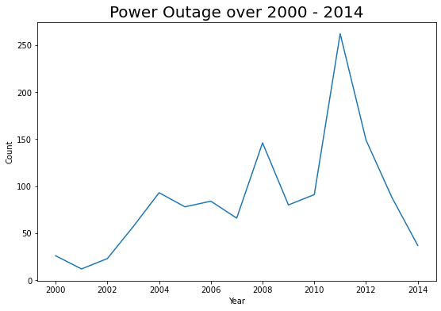

```python
plt.figure(figsize=(9,6))
plt.title('Power Outage over 2000 - 2014', fontsize=20)
sns.lineplot(year_table.Year, year_table.Cause, ci = None)
plt.ylabel('Count')
plt.show()
```

Interestingly, the graph shows that the power outage tends to increase until 2011. I thought it would be decreasing because technology always improves things as time goes. Then, let me split the cases by causes.

```python
year_cause_table = df.groupby(['Year', 'Reason'], as_index = False)
year_cause_table = year_cause_table.count()
year_cause_table.head()
```

|  | Year | Reason | Cause | Area | Affected |
| --- | --- | --- | --- | --- | --- |
| 0 | 2000 | Attack | 1 | 1 | 1 |
| 1 | 2000 | Others | 10 | 10 | 10 |
| 2 | 2000 | System | 2 | 2 | 2 |
| 3 | 2000 | Weather | 13 | 13 | 13 |
| 4 | 2001 | Others | 1 | 1 | 1 |

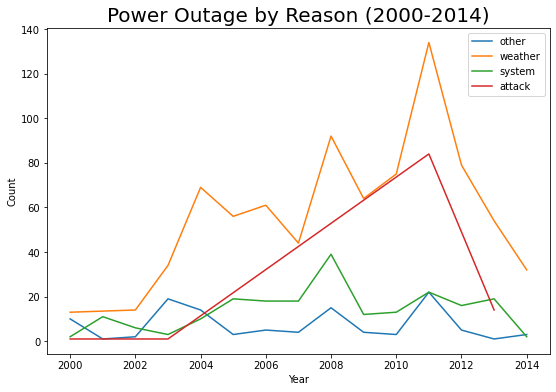

```python
other = year_cause_table[year_cause_table.Reason == 'Others']
weather = year_cause_table[year_cause_table.Reason == 'Weather']
system = year_cause_table[year_cause_table.Reason == 'System']
attack = year_cause_table[year_cause_table.Reason == 'Attack']

plt.figure(figsize=(9,6))
plt.title('Power Outage by Reason (2000-2014)', fontsize=20)
sns.lineplot(other.Year, other.Cause, ci = None)
sns.lineplot(weather.Year, weather.Cause, ci = None)
sns.lineplot(system.Year, system.Cause, ci = None)
sns.lineplot(attack.Year, attack.Cause, ci = None)
plt.legend(["other", 'weather', 'system', 'attack'])
plt.ylabel('Count')
plt.show()
```

### 3.2 Bar Plot - Power Outage Count by Area

Now, I am going to make a horizontal bar plot to show top 50 areas that frequently experienced the power outage. Since there are too many areas, I decided to include only 50 areas for simplicity. By doing this, I expect that coastal areas would be observed.

```python
area_table = df.groupby(['Area'], as_index = False)
area_table = area_table.count().sort_values(by=['Cause'],ascending=False)
area_table = area_table.head(50)
```

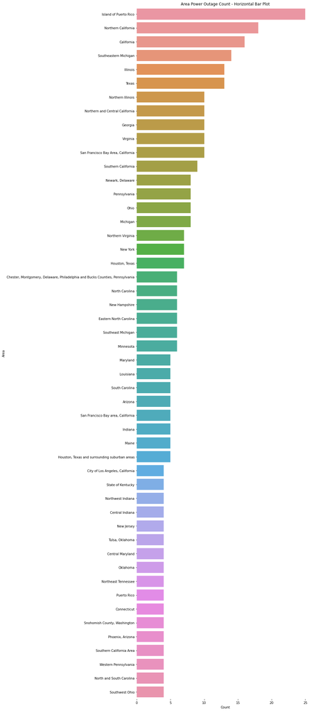

```python
plt.figure(figsize=(10, 40))
sns.barplot(x="Cause", y='Area', data = area_table)
sns.despine(left=True, bottom=True)
plt.xlabel('Count')
plt.ylabel('Area')
plt.title('Area Power Outage Count - Horizontal Bar Plot')
plt.show()
```

### 3.3 Pie Chart - Power Outage Factors

As usual, I will count the number of cases by reason.

```python
pie_table = df.groupby(['Reason'], as_index = False)
pie_table = pie_table.count()
pie_table = pie_table.drop(['Year', 'Area'], axis=1)
pie_table.rename(columns={'Cause': 'Count'}, inplace = True)
pie_table.head()
```

|  | Reason | Count | Affected |
| --- | --- | --- | --- |
| 0 | Attack | 150 | 150 |
| 1 | Others | 111 | 111 |
| 2 | System | 210 | 210 |
| 3 | Weather | 821 | 821 |

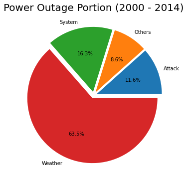

```python
plt.figure(figsize=(6,6))
plt.title('Power Outage Portion (2000 - 2014)', fontsize=20)
plt.pie(pie_table.Count, explode =(0.05, 0.05, 0.05, 0.05), labels=pie_table.Reason, autopct='%1.1f%%')
plt.show()
```

Alright, as I expected earlier, 'Weather' takes about 63.5% of the entire power outage, 'Attack' takes about 11.6%, 'System Failure' takes about 16.3%, and 'Others' takes about 8.6%.

### 3.4 Heatmap - Finding Correlation between Reasons and the Number of Affected Customers

```python
df['Affected'] = df['Affected'].str.replace('None', '0')
df['Affected'] = df['Affected'].str.replace(',', '')
df['Affected'] = pd.to_numeric(df['Affected'], errors='coerce').fillna(0).astype(np.int64)
```

For simplicity, I ignored "Affected" values that contain string descriptions such as "None", "Approximate...", and "Unknown...".

```python
temp_sum = df.groupby(['Year', 'Reason'], as_index = False)
temp_sum = temp_sum.sum()
temp_sum = temp_sum.groupby(['Year'], as_index = False).sum()

temp_count = df.groupby(['Year', 'Reason'], as_index = False)
temp_count = temp_count.count()
temp_count.drop(['Area', 'Affected'], axis=1, inplace=True)
temp_count.rename(columns={'Cause': 'Count'}, inplace = True)
temp_count = pd.pivot_table(temp_count, index='Year', columns='Reason', values='Count')
temp_count = temp_count.fillna(0)
```

"temp_sum" has the number of affected customers by year.  
"temp_count" has the number of the power outage cases by "Reason" factor and year.

```python
merged_table = pd.merge(temp_sum, temp_count, on='Year')
marged_table = merged_table.replace(np.nan, 0)
merged_table
```

|  | Year | Affected | Attack | Others | System | Weather |
| --- | --- | --- | --- | --- | --- | --- |
| 0 | 2000 | 2423081 | 1.0 | 10.0 | 2.0 | 13.0 |
| 1 | 2001 | 1299490 | 0.0 | 1.0 | 11.0 | 0.0 |
| 2 | 2002 | 5024651 | 1.0 | 2.0 | 6.0 | 14.0 |
| 3 | 2003 | 12589860 | 1.0 | 19.0 | 3.0 | 34.0 |
| 4 | 2004 | 17362071 | 0.0 | 14.0 | 10.0 | 69.0 |
| 5 | 2005 | 17488825 | 0.0 | 3.0 | 19.0 | 56.0 |
| 6 | 2006 | 12660231 | 0.0 | 5.0 | 18.0 | 61.0 |
| 7 | 2007 | 7264696 | 0.0 | 4.0 | 18.0 | 44.0 |
| 8 | 2008 | 27354271 | 0.0 | 15.0 | 39.0 | 92.0 |
| 9 | 2009 | 9445988 | 0.0 | 4.0 | 12.0 | 64.0 |
| 10 | 2010 | 11691129 | 0.0 | 3.0 | 13.0 | 75.0 |
| 11 | 2011 | 26192819 | 84.0 | 22.0 | 22.0 | 134.0 |
| 12 | 2012 | 22680439 | 49.0 | 5.0 | 16.0 | 79.0 |
| 13 | 2013 | 8828313 | 14.0 | 1.0 | 19.0 | 54.0 |
| 14 | 2014 | 12442425 | 0.0 | 3.0 | 2.0 | 32.0 |

Now, we have a table merged on "Year". The table contains the number of affected customers by year and its count by "Reason" factors. For the part that I used "pivot_table", I had to reshape the data frame so that it has numeric represtation to make correlation.

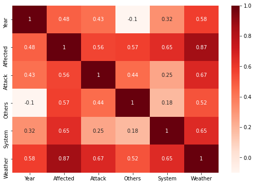

```python
plt.figure(figsize=(9,6))
sns.heatmap(merged_table.corr(), annot=True, cmap='Reds')
plt.show()
```

I used Seborn Heatmap library to visualize the correlation of columns. The higher and darker the relationship is strong. Based on the heatmap, "Weather" has a stong correlation of 0.87 with "Affected". "System" has the second strong correlation of 0.65 with "Affected" and 0.57 for "Others" and 0.56 for "Attack".

## 4. MachinLearning - Linear Regression

Now, I am going to make a model that predicts the number of affected customers considering the Reason factors.  
First, I am going to split the dataset into two. One for the training dataset and the other for the test dataset.

```python
x = merged_table[['Attack', 'Others', 'System', 'Weather']]
y = merged_table[['Affected']]
x_train, x_test, y_train, y_test = train_test_split(x,y,train_size = 0.8, test_size=0.2)
```

I splited the dataset with ratio of 8:2. 8 for the training-set and 2 for the test-set. Then, I will need to make a model with Linear Regression.

```python
lm = LinearRegression()
lm.fit(x_train, y_train)
```

```
LinearRegression()
```

Now, I have a linear regression model that predicts the number of customers affected by the power outage. Then, now i am going to find the accuracy of my model so that I can compare it with the actual one.

```python
acc_train = lm.score(x_train, y_train)
acc_test = lm.score(x_test, y_test)

print("Accuracy on training Data: {:.3f}".format(acc_train))
print("Accuracy on test Data: {:.3f}".format(acc_test))
```

```
Accuracy on training Data: 0.752
Accuracy on test Data: 0.842
```

So, we are good to use this model to predict.